# Le secret bancaire suisse au XXe siècle dans le *Journal de Genève* et la *Gazette de Lausanne*

Yann Bolliger, Pietro Carta, Romain Mendez

# Contexte historique

La place financière suisse a vu une énorme croissance presque non perturbée tout au long du XXème siècle. Cela a été possible grâce à la neutralité et la stabilité de la Suisse notamment en période de guerre mais surtout aussi grâce au «secret bancaire» . Ce dernier est déjà une pratique des banques suisses au XIXème siècle quand les grandes banques[^1] commencent à dominer la place financière suisse. Ces banques-là profitent considérablement des afflux de capitaux étrangers. Pendant la Grande Guerre les banques utilisent le secret bancaire pour attirer les capitaux étrangers fuyant de lourdes fiscalités implémentées par les pays en guerre . Cela permet aux banques de devenir une force majeur à l’échelle de la finance mondiale ainsi qu’une influence principale dans la politique nationale. En effet, l’influence des banques dans la politique fédérale est tellement grande que le secret bancaire est renforcé par la loi sur les banques en 1934, sans susciter de grands débats au parlement .

L’introduction de cette loi est vue aujourd’hui comme la troisième étape de l’avènement des paradis fiscaux contemporains . La première étape étant les états du Delaware et du New Jersey qui attirent des entreprises avec des taxes très basses vers la fin du XVIIIème siècle. Une décision des juges anglais de 1929 disant qu’une entreprise qui a son siège à l’étranger n’est pas imposable en Angleterre a marqué la deuxième étape. Comme ces deux étapes ont eu lieu dans des pays anglophones le terme anglais *tax haven* a été repris en français comme *paradis fiscal*.

Avec la Seconde Guerre mondiale, de nouveau, la place financière Suisse profite de la fuite de capitaux étrangers provenant de pays en guerre. Sous couvert de la neutralité, les banques suisses arrivent à maintenir des liens très proches avec tous les belligérants, mais surtout avec les forces de l’Axe, ce qui mène la Suisse dans une grande isolation diplomatique à la fin de la guerre. Par exemple, les États-unis gèlent les avoirs des banques suisses déposés en Amérique déjà en 1941. Néanmoins la diplomatie suisse obtient le maintien du secret bancaire contre les revendications des vainqueurs. Cela marque le début d’une période de croissance sans précédent pour la place financière pendant les «trente glorieuses» .

Après la guerre, à l’étranger, le secret bancaire suisse reste objet de fortes critiques. Les plus importants critiques étant les États-unis et la France . Dans la deuxième partie du XXe siècle, la diplomatie américaine obtient de la Suisse quelques concessions qui ont toutefois très peu d’impact. Après 1968, des critiques intérieures commencent a troubler le consensus de la population suisse en faveur du secret bancaire. Au même moment, de nombreux scandales impliquant les grandes banques Suisse font surface. L’organisation tiers-mondiste “Déclaration de Berne” se forme et dit lutter contre “l’exploitation” des pays en voie de développement par le secteur financier et industriel suisse. Cette organisation lance, conjointement avec le Parti Socialiste, une initiative populaire contre le secret bancaire en 1984[^2]. L’initiative populaire est toutefois rejetée par une forte majorité des suisse (73%).

Avec l’accord du peuple, les grandes banques ont ainsi maintenu le statut privilégié de la place financière pendant plus que 50 ans. Ils l’ont défendu contre la pression de l’intérieur et de l’extérieur. Ce n’est seulement après la crise financière en 2007 que, sous la pression de l’OCDE, le secret bancaire est aboli pour les citoyens de pays membres de l’OCDE sauf la Suisse . Il est à noter que des lois similaires existaient dans d’autres pays européens qui ont tous graduellement cédé sous la pression des critiques. Pour beaucoup c’est via la construction européenne que leurs lois sont influencées pour limiter le secret bancaire .

Dans le cadre de notre recherche nous essayerons de retrouver ces événements dans la presse romande. Celle-ci étant plutôt proche des cercles financiers – surtout le «journal de Genève» –, nous évaluerons aussi leurs positions sur le secret bancaire et si cette proximité peut-être confirmée par les articles du corpus. Afin de nous demander, comment évolue la couverture médiatique du secret bancaire au XXe siècle?

# Information Bibliographiques

## Sources primaires

Nous admettons dans notre analyse les articles extrait de la *Gazette de Lausanne* et du *Journal de Genève*, pendant la période 1900-1995. Pour restreindre l’analyse aux articles pertinents, le corpus d’articles des deux journaux sera filtré en ne gardant que les articles contenant des mots clés, repérés à travers l’analyse de nos autres sources primaires et la littérature secondaire.

Les sources primaires que nous analysons, outres que les archives du Temps, sont de nature politique, juridique, ou diplomatique. La “Déclaration de Berne” en collaboration avec le Parti Socialiste publie en 1978 le pamphlet “Les Secrets du secret bancaire suisse” où les conséquences internationales et intérieures du secret bancaire sont dénoncées. Cet ouvrage nous expose au débat qui entourait le sujet pendant les années 70 et 80.

## Littérature secondaire

Nous considérons deux types de littérature secondaire, un sur l’histoire financière suisse par Sébastien Guex et Malik Mazbouri . Et un autre type sur les spécificités du cas suisse au niveau international, analysé par Henry Meier .

## Mots-clés

Notre corpus consistant de milliers d’articles différents, il est nécessaire d’isoler des mots-clés caractérisant notre sujet. C’est avec les termes ci-dessous que nous trouvons le plus d’articles en lien avec le sujet.

Secret bancaire, place financière suisse, banques suisses, forfait fiscal, paradis fiscal, corruption, affaire Chiasso, argent sale, blanchiment, PIB, emploi, croissance.

# Outils Méthodologiques

Afin de pouvoir traiter en un temps raisonnable notre corpus de texte, plusieurs pistes d’analyse s’offrent à nous. Dans un premier temps un filtrage des articles s’impose, pour ne travailler que sur des articles contenant des termes importants du sujet (voir la liste de terme clés dans la précédente partie). Aussi, nous pouvons lier l’apparition du terme secret bancaire à des événements liés au sujet et voir l’évolution de la popularité du terme au fil du temps comme dans la figure 1.

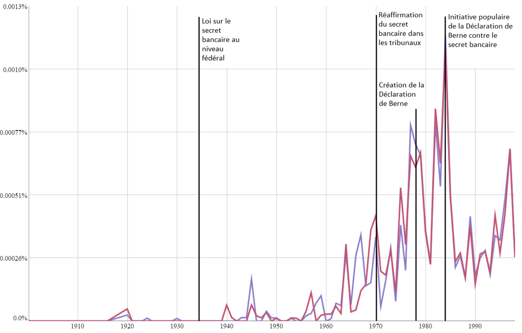

N-gram du terme "secret bancaire" dans les journaux *Journal de Genève* (bleu) et *Gazette de Lausanne* (rouge).

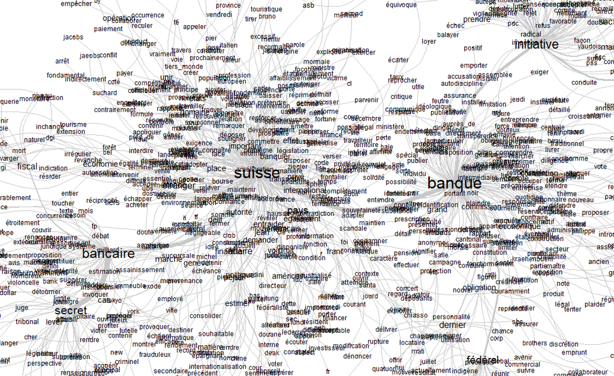

Zoom dans la visualisation sur les articles contenant les mots "secret bancaire" dans l’année 1984 dans le *Journal de Genève*

Ensuite, nous pensons procéder à des visualisations du corpus filtré avec des logiciels tel que Iramuteq afin de voir les relations entre les mots (quels mots se suivent souvent, et quelle est leur connotation).

Avec de telles visualisation nous voulons trouver plus de mots-clés. Par exemple dans la figure 2, nous pouvons voir que les mots "secret" et "bancaire" sont peu liés aux mots "initiative" et "populaire" en 1984 (alors qu’une initiative populaire sur le sujet du secret bancaire est lancée cette année là). Ici on peut voir que les thèmes en question sont toujours liés à la Suisse en elle-même. Dans les mots autour de "initiative" on peut trouver d’autres mots forts comme "balayer" ou "socialiste", ce qui indique par exemple une certaine position dans les articles parlant de l’initiative.

Nous voulons tenter de répondre aux questions suivantes : A qui est-ce que la parole est-elle donnée dans les journaux ? Est-ce que les acteurs étrangers s’expriment ? Et surtout, est-ce que les banques sont promues ?

Cette dernière question nous amène à nous demander, comment détecter si les banques sont promues et/ou critiquées ? L’idée actuelle est de voir si des mots-clés traditionnellement associés au point de vu positif sont dans les articles abordant le sujet ou non (tel que PIB, emploi, croissance ...).

Nous pensons donc utiliser les sources secondaires pour forger une attente du corpus, ce à quoi nous nous attendons après ce type d’analyse. C’est-à-dire par exemple utiliser les informations recueillies sur les rédactions des journaux dans la conférence du 31 Octobre afin de vérifier nos résultats avec les différentes tendances des rédactions de ces deux journaux. Cela devrait pouvoir nous servir de garde-fou sur nos résultats. Une fois ce travail accompli, nous nous servirons des résultats pour analyser la position idéologique des journaux au fil de la période étudiée.

## Méthodologie

Notre idée centrale est de porter l’analyse sur la différence entre les deux journaux et leur évolution dans le temps. La méthodologie détaillée ici est donc appliquée sur les deux journaux séparément et elle est organisé de manière suivante:

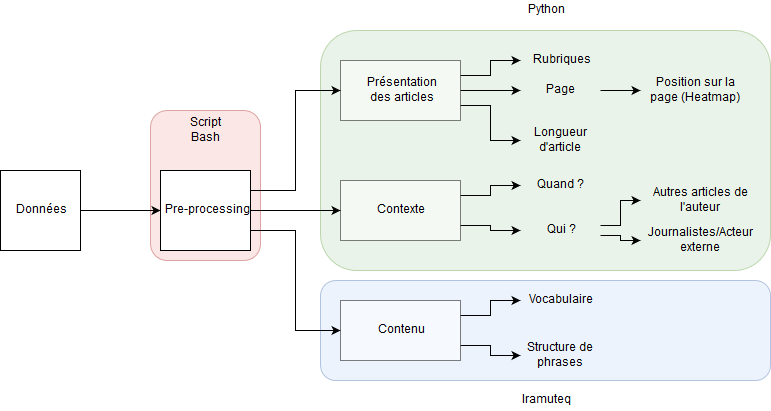

Organisation et outils de l’analyse.

### Pre-processing

Pour l’explorer de manière plus rapide, nous devons réduire le corpus de base qui se constitue des articles de la *Gazette de Lausanne* (*GDL*) et du *Journal de Genève* (*JDG*) sortis entre 1900 et 1999.

Nous créons trois corpus. Le plus grand est constitué de tous les articles, décomprimés (du format `bzip2`) et sans méta-données concernant la position des mots sur la page. Nous nous servons de ce corpus-là pour des questions qui regardent l’entièreté des journaux, comme la longueur en page du journal à une certaine date.

Le deuxième corpus se limite aux articles de caractère financier et est extrait du premier corpus par la recherche des mots clés suivants:

- secret bancaire
- place financière
- banques suisses
- forfait fiscal
- paradis fiscal
- affaire Chiasso
- argent sale
- blanchiment

Nous utilisons ce corpus de ~35’000 articles pour nous comparer avec notre troisième corpus, sélectionné par le seul mot clé “secret bancaire”, contentant environ 1700 articles. De cette façon, nous pouvons déterminer si une certaine tendance de ce corpus est vraiment signifiante, ou si elle apparaît dans tout le corpus financier.

### Statistiques de base

Nous commençons en calculant certaines statistiques de base, telles que le numéro de page, la longueur et la date d’un article. Nous reproduisons donc le N-Gram dans le temps, pour les articles contenant “secret bancaire” par année.

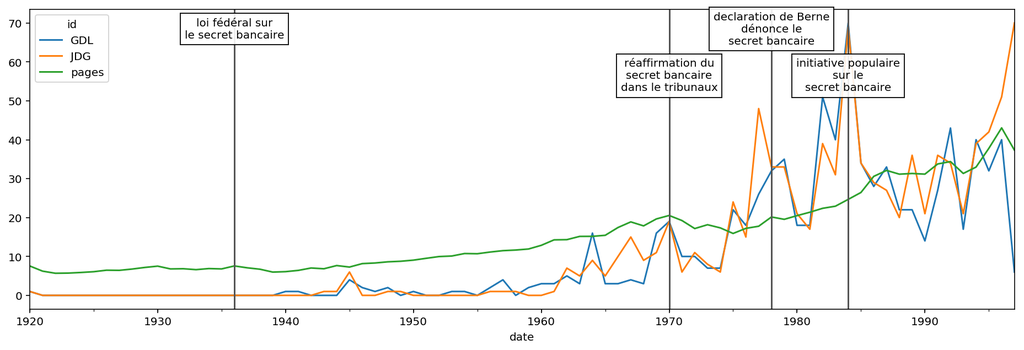

Apparitions du terme “secret bancaire” dans les deux journaux au cours du temps

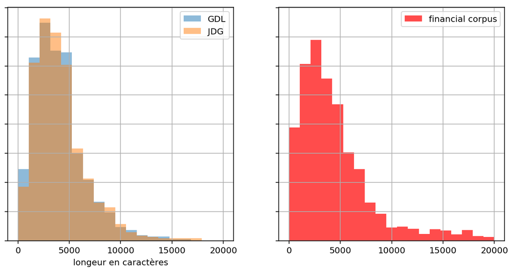

Distribution de la longueur des articles

Nous examinons aussi, à l’aide d’un histogramme de la page de l’article, la distribution de la position des articles sur le secret bancaire. Pour mieux interpréter les résultats de cette analyse, nous trouvons la longueur du journal pour chaque date et calculons ainsi la position relative de l’article dans le journal. Nous cherchons enfin à voir si des rubriques spécialisées traitent le sujet, en examinant des nuages de points corrélants la date et la page des articles en question. Des ligne horizontales isolées constituerait un indice d’une rubrique permanente.

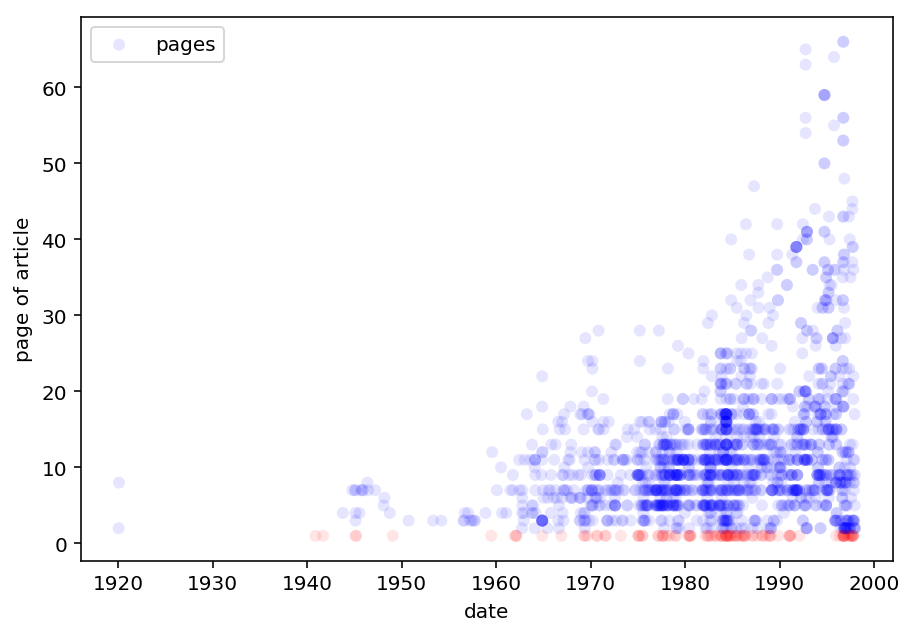

Nuage de points de la page des articles dans le temps

En comparant le nombre d’article en première page, nous constatons que la fréquence d’une première page pour un article sur le secret bancaire est de 5% dans la *GDL* et 6% dans le *JDG*. Alors que la fréquence d’une première page pour un article générique financier est de 2% pour la *GDL* et 3% pour la *JDG*.

### Analyse des auteurs

La méta-donnée la plus importante après la date qui est traitée en haut est l’auteur d’un article. Nous analysons deux catégories d’auteurs.

#### Agences de presse

Beaucoup d’articles de journal proviennent d’agences de presse externes à la rédaction. Nous classifions les articles des agences suivantes:

- ATS: Agence télégraphique suisse
- AFP: Agence France-Presse
- Reuters
- AP: Associated press

Ainsi nous trouvons que pour les articles du secret bancaire le taux d’articles issus d’agences et 10% plus haut que dans le corpus financier.

#### Journalistes

Même si l’auteur n’est pas toujours indiqué – surtout dans la première moitié du siècle – nous arrivons à extraire des données sur les journalistes. Au moyen d’une liste de noms d’auteurs[^3] et des initiales à la fin de l’article, nous pouvons attribuer des auteurs à plus que 2600 articles.

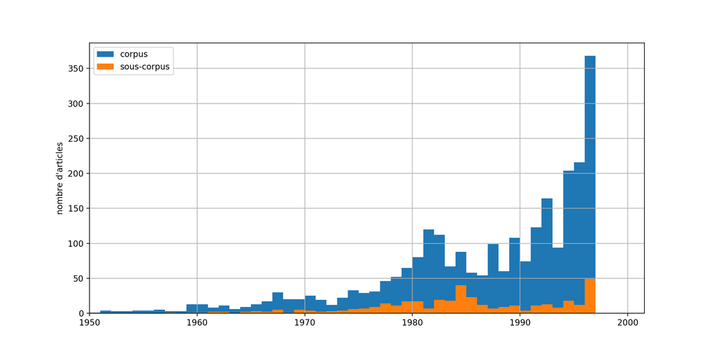

Articles avec auteur attribué

Cette attribution nous permet de poser les questions suivantes: Est-ce qu’un journaliste est actif dans le deux journaux en même temps? Est-ce qu’il écrit en moyenne plus souvent sur le secret bancaire que sur d’autres sujets?

Comme exemple, nous voyons que les deux auteurs du *JDG* qui ont écrit le plus sur le secret bancaire sont Jean-Luc Lederrey (41 articles) et Jacques-Simon Eggly (29 articles). Les deux sont aussi actifs dans la *GDL* et cela même avant la fusion des rédactions en 1991. En plus, une recherche LinkedIn ou Wikipédia révèle que les deux travaillaient aussi dans le monde banquier[^4] ou dans la politique libérale[^5].

### Analyse du contenu

L’analyse de contenu se limite au corpus “secret bancaire”. Dans un premier temps nous produisons des graphiques d’analyses de similitudes pour les deux journaux.

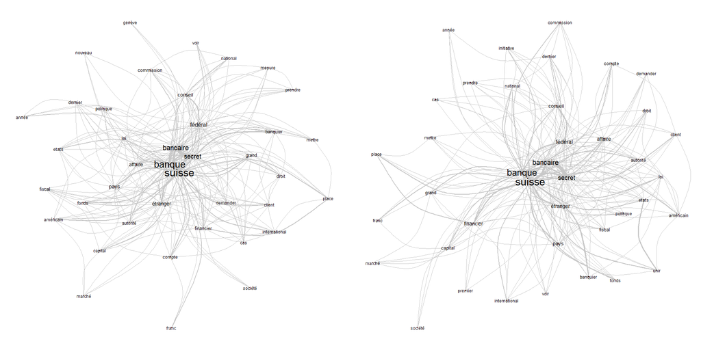

Graphes de similitudes du *JDG* (gauche) et de la *GDL* (droite)

Afin de rendre les visuels utilisables, nous affichons ici seulement 40 mots (autres que préposition et déterminants). Afin de ne pas surcharger l’image, seuls les termes qui apparaissent plus de 50 fois ensemble sont montrés reliés dans le graphe.

En suite, toujours dans un esprit de comparaison des journaux, nous produisons deux dendrogrammes sur les journaux.

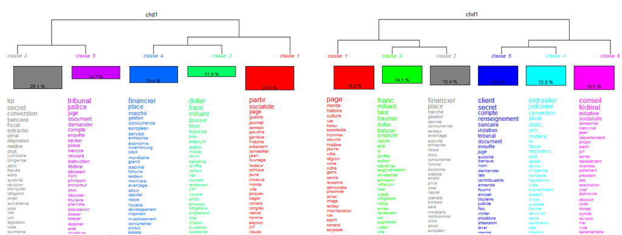

Dendrogrammes du *JDG* (gauche) et de la *GDL* (droite)

Cela nous permet de comparer le langage utilisé dans les deux journaux, nous voyons qu’un journal a été organisé en cinq clusters et l’autre en six, montrant une divergence dans la façon d’aborder le sujet. Les champs lexicaux sont proches mais cela nous n’apporte encore rien sur le contexte d’utilisation des mots.

En poussant cette idée plus loin, nous obtenons les graphes AFC.

Cette visualisation nous présente les distances entre des mots dans le texte, et nous permet de voir qu’entre les deux journaux le vocabulaire employé est plus variable dans la gazette de Lausanne.

Avec ces informations, nous pouvons déjà observer que le style d’écriture des articles est différent. Nous observons par exemple que la *GDL* semble mettre ensemble des articles qui parlent de secret bancaire avec des articles qui parlent d’affaires judiciaires (avec les mots “secret”, “bancaire” proche du mot “judiciaire”).

### Critique et difficultées

Notre analyse est particulièrement perturbée par les problèmes de l’OCR de basse qualité. Car, les termes que nous tentons d’isoler sont plutôt long et une erreur de reconnaissance est bien plus probable.

Un autre problème est que le format de reconnaissance des articles est assez limité. Il a fallu que nous allions chercher le nom des auteurs manuellement, cependant nous avons observé que mettre le nom de l’auteur sur un article de journal ne devient courant qu’à partir des années 60, limitant nos capacité d’analyse avant cette période.

Nous avons réussi à contourner ce problème en utilisant une liste de noms de journalistes ayant travaillé pour le *JDG*. Cependant nous n’avons pas trouvé une telle liste pour la *GDL*.

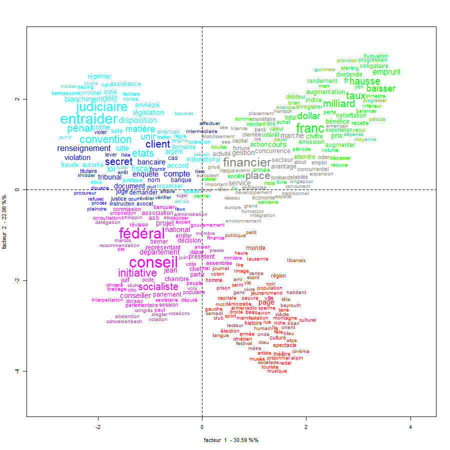

AFC de la Gazette de Lausanne

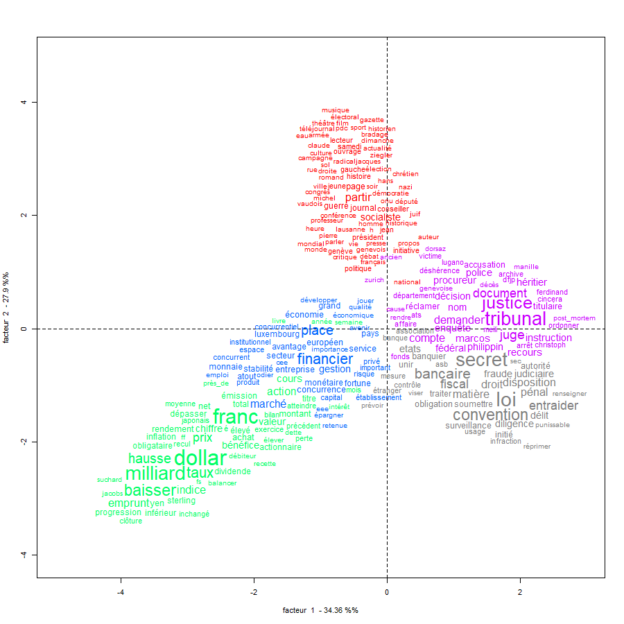

AFC du journal de Genève

## Analyse

### Intérêt des journaux au sujet du secret bancaire

Le sujet du secret bancaire a suscité une centaine de premières pages au sein des deux journaux de 1940 jusqu’à la fin des années 90. Ce chiffre relativement petit nous permet de lire quelques premières pages pour mieux contextualiser nos autres analyses.

De manière générale et excluant l’année 1984 de l’initiative populaire au même sujet, le secret bancaire n’est pas un sujet très important dans le corpus financier des deux journaux. Le sous-corpus “secret bancaire” ne constitue que 5% des articles du corpus financier, qui lui-même ne contient qu’une petite partie de tous les articles. Il est remarquable que dans le sous-corpus la proportion d’articles qui proviennent d’agences de presse est de dix pour-cent plus élevée que dans le corpus financier (29% pour le “secret bancaire”, 18% pour le financier). Cela montre que le sujet a moins d’importance pour les rédactions, qui utilisent souvent que des dépêches pour en parler.

Pour cerner l’origine de cet intérêt, nous comparons la fraction de dépêches venant de l’étranger à celles de l’Agence télégraphique suisse (ATS). La figure [percentage] montre comment cette fraction évolue dans le sous-corpus au cours du temps. Nous trouvons deux périodes où les dépêches étrangères ont une certaine présence: 1972 – 1977 et 1986 – 1992. Ce sont des périodes relativement calmes, où à l’intérieur de la Suisse le sujet n’est pas d’actualité.

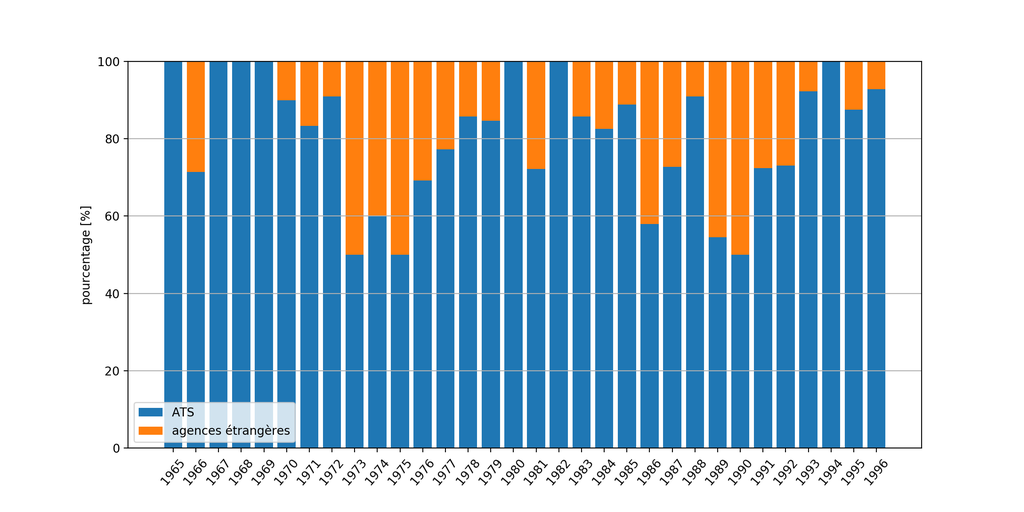

[percentage] Distribution relative des articles d’agences de presse étrangères pour le “secret bancaire”.

La série temporelle du nombre d’articles par catégorie d’auteur (fig. [categorie]) met en évidence une nette chute de l’utilisation de dépêches étrangères qui parlent du secret bancaire pendant exactement la période avant la votation de 1984. Vue la forte orientation politique des deux rédactions contre l’initiative, on peut supposer que les articles d’agences étrangères qui ne concernent pas l’initiative sont minimisés, pour ne pas détourner l’attention des lecteurs.

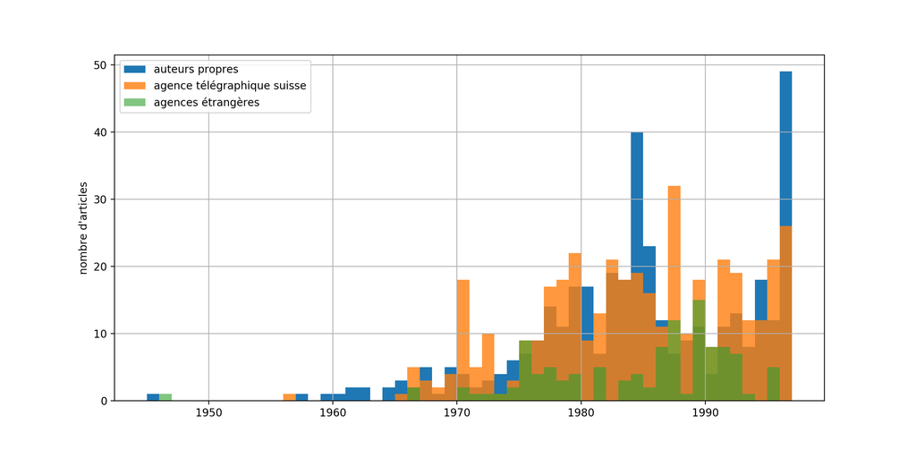

[categorie] Nombre d’articles par catégorie d’auteur au cour du temps.

Par la lecture des premières pages, on peut trouver le ensemble suivant de périodes principales dans l’histoire du secret bancaire:

- 1940–45: Le secret bancaire est menacé de l’intérieur par le gouvernement, à cause de l’économie de guerre, et de l’extérieur par les futures nations unies, qui désirent l’entraide judiciaire et fiscale.
- 1946–65: Période de calme où aucune attaque importante n’est montée contre le secret bancaire. Quelques frictions avec la France se résolvent en une impasse.
- 1966–70: Tensions et efforts diplomatiques avec les États-Unis, qui critiquent durement le secret bancaire qui leur empêche d’enquêter efficacement la criminalité organisée. Cela se résout avec des accords bilatéraux qui concèdent très peu à la justice américaine.
- 1975–84: Tumultes intérieurs vis au secret bancaire. L’économie en récession et la force du Franc Suisse dans les marchés de devises portent les milieux politiques socialistes à attaquer le secret bancaire comme responsable. Le débat intérieur continue jusqu’en 1984, quand l’initiative socialiste contre le secret bancaire est repoussée.
- 1987–89: Pressions américaines poussent la Suisse à approuver la levée du secret bancaire dans le cas de manipulation des marchés (*insider trading*), un délit qui n’était pas persécuté en Suisse jusqu’alors.
- 1996–suite: Affaire des fonds juifs en déshérence. Le conseil national vote à l’unanimité pour la levée du secret bancaire pour la commission Bergier.

La tonalité du discours dans les deux journaux au cours de ces périodes est surtout intéressante. Dans la première période, le ton est positif et tranquille. En 1975, le ton change rapidement: des articles écrits par Marian Stepcinsky, Jean-Luc Lederrey, et par le futur politicien libéral Jacques-Simon Eggly gagnent souvent la première page. Ces articles sont des pièces d’opinion, souvent virulentes, où les avantages du secret bancaire sont rappelés. Contrairement aux périodes précédentes, où les avantages du secret bancaire ont été considéré trop évidents pour les souligner. Ces articles d’opinion forment une véritable propagande en faveur du secret bancaire et contre les socialistes, et donnent de précises indications de vote dans le mois avant l’initiative.

La tonalité des articles redevient enfin plus objective et s’assouplie, après que l’initiative soit rejeté. Les lois sur la manipulation des marchés et la commission Bergier ne sont pas perçus comme menace essentielles à la stabilité de la place financière.

### Comparaison des deux journaux

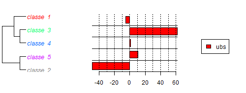

D’autres tests similaires pointent vers d’autres division, ou les articles utilisants des termes juridiques et/ou techniques précis (comme “bancaire”, “fraude”, “autorité”) vont concentrer les articles dans une même classe. Mais nous voyons aussi que les termes qui ramènent au nom des banques sont dissociés des groupes parlant de l’actualité du secret bancaire.

Du côté de la *GDL*, nous trouvons six groupes. Là ou le *JDG* semble avoir des classes qui sont basées sur des sujets différents (économie, affaires judiciaires, légal), dans la *GDL* il semble que les événements marquants de la période génèrent plus d’attentions. Car, on retrouve une classe avec des mots rappelant des affaires judiciaires. Dans cette classe on retrouve des termes tels que “renseignement”, “tribunal”, “violer”… Cela semble indiquer que les différents scandales ou affaires judiciaires entourant le secret bancaire sont perçues comme plus importants dans la *GDL* que le *JDG*. Cependant, ici comme dans le *JDG* le nom des banques suisse apparaît plutôt dans le groupe d’articles référençant des termes financiers plus généraux, la classe 3, qui est très similaire à la classe 3 dans l’analyse du *JDG* (avec les noms de devises, des quantités)

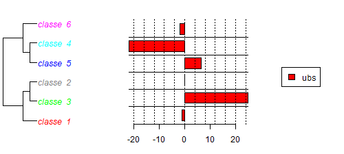

[percentage] Chi²-Test du terme “ubs” dans la *GDL*.

Tout ceci semble indiquer que, même si l’emphase apportée aux différents événements entourant le secret bancaire est différente entre les deux journaux, les deux semblent aussi dissocier les banques du sujet même du secret bancaire.

### Conclusions

L’analyse linguistique nous montre que la *GDL* donne plus d’importance aux affaires concrètes et le *JDG* plus au coté abstrait législatif, bien que aucun des deux journaux ne pointe jamais du doigt. Dans les deux journaux, le secret bancaire est abordé dans un contexte politique plutôt que financier, en défendant ces principes à la base plutôt qu’en montrant les inconvénients qu’il cause aux fiscs et aux investigateurs internationaux.

[^1]: Union de Banques Suisses, Schweizerische Kreditanstalt (Crédit Suisse), Schweizerische Volksbank, Banque Leu, Eidgenössische Bank, Société de Banque Suisse, Banque Commerciale de Bâle et le Comptoir d’Escompte
[^2]: Initiative populaire “contre l’abus du secret bancaire et de la puissance des banques”. https://www.bk.admin.ch/ch/f/pore/va/19840520/index.html
[^3]: Cette liste était obtenue de la page [Wikipédia du *Journal de Genève*](https://fr.wikipedia.org/wiki/Journal_de_Gen%C3%A8ve).
[^4]: [Jean-Luc Lederrey sur LinkedIn](https://ch.linkedin.com/in/lederrey-jean-luc-1456b717).
[^5]: [Jean-Simon Eggly sur Wikipédia](https://fr.wikipedia.org/wiki/Jacques-Simon_Eggly).